# Final_Group-22_Project

## 👨‍💻 Project Contributors

This data analysis project has been collaboratively developed as part of our academic curriculum. We have worked together on data cleaning, analysis, visualization, and insight generation to understand cultural trends through movie metadata.

### 👤 Member 1

- **Name:** Mohammad Kaif Khan
- **Enrollment Number:** 2200101545
- **Email:** kkaifkhan@student.iul.ac.in

### 👤 Member 2

- **Name:** Mohammad Rayyan
- **Enrollment Number:** 2200101994
- **Email:** 123krrayyan@gmail.com

**Institution:** Integral University, Lucknow

**Course:** Data Analysis with Python

# 🎬 Cultural Trends Through Decades via Movie Metadata

## 📘 Project Description

This project analyzes **movie metadata** to identify evolving **genre preferences** and **cultural shifts** over time. By examining attributes such as *genres*, *release dates*, *popularity*, *revenue*, and *vote averages*, we aim to uncover trends that reflect changing audience tastes and societal influences across decades.

## 📦 Dataset

The dataset (`movies.csv`) contains metadata for thousands of movies, including:

- **budget**: Movie budget in USD
- **genres**: List of genres in JSON format
- **release_date**: Release date of the movie
- **revenue**: Revenue generated in USD
- **popularity**: Popularity score
- **vote_average**: Average user rating
- **runtime**: Movie duration in minutes
- **keywords, production_companies, spoken_languages**: Additional metadata for cultural insights

## 🎯 Objectives

1. Clean and preprocess the dataset to handle missing values, JSON parsing, and data type conversions.
2. Extract temporal data to analyze movie trends by **year** and **decade**.
3. Create **9–10 insightful visualizations** to highlight genre popularity, revenue trends, and cultural changes.
4. Provide **data-driven insights** into how societal preferences have evolved over time.

## 📚 Import Libraries

We import the necessary Python libraries for data analysis and visualization, including **pandas** for data manipulation, **matplotlib** and **seaborn** for plotting, **plotly.express** for interactive charts, **wordcloud** for creating word clouds, **folium** for map visualizations, **json** for parsing JSON columns, **ast** for safely evaluating string representations of Python objects, **random** for generating random coordinates for plotting, and **numpy** for numerical operations.

This sets up the environment for loading and analyzing the *movies.csv* dataset.

```python
import pandas as pd
import matplotlib.pyplot as plt
import seaborn as sns
import plotly.express as px
from wordcloud import WordCloud
import folium
import random
import ast
import json
import numpy as np

pd.set_option('display.max_columns', None)
sns.set(style='whitegrid')
```

## 📂 Load Data

We load the **movies.csv** dataset into a pandas DataFrame, *df*, which contains movie metadata such as genres, release dates, budgets, and revenues. The shape of the DataFrame is displayed to confirm the number of rows and columns.

This step initializes the dataset for further exploration and preprocessing.

```python
df = pd.read_csv('movies.csv')
print("File Read Successfully!")
df.shape
```

```
File Read Successfully!
```

```
(4803, 20)
```

### 🧾 Printing the First 5 Rows of the Dataset using `head()` Function

```python
df.head()
```

|  | budget | genres | homepage | id | keywords | original_language | original_title | overview | popularity | production_companies | production_countries | release_date | revenue | runtime | spoken_languages | status | tagline | title | vote_average | vote_count |
| --- | --- | --- | --- | --- | --- | --- | --- | --- | --- | --- | --- | --- | --- | --- | --- | --- | --- | --- | --- | --- |
| 0 | 237000000 | [{"id": 28, "name": "Action"}, {"id": 12, "nam... | http://www.avatarmovie.com/ | 19995 | [{"id": 1463, "name": "culture clash"}, {"id":... | en | Avatar | In the 22nd century, a paraplegic Marine is di... | 150.437577 | [{"name": "Ingenious Film Partners", "id": 289... | [{"iso_3166_1": "US", "name": "United States o... | 2009-12-10 | 2787965087 | 162.0 | [{"iso_639_1": "en", "name": "English"}, {"iso... | Released | Enter the World of Pandora. | Avatar | 7.2 | 11800 |
| 1 | 300000000 | [{"id": 12, "name": "Adventure"}, {"id": 14, "... | http://disney.go.com/disneypictures/pirates/ | 285 | [{"id": 270, "name": "ocean"}, {"id": 726, "na... | en | Pirates of the Caribbean: At World's End | Captain Barbossa, long believed to be dead, ha... | 139.082615 | [{"name": "Walt Disney Pictures", "id": 2}, {"... | [{"iso_3166_1": "US", "name": "United States o... | 2007-05-19 | 961000000 | 169.0 | [{"iso_639_1": "en", "name": "English"}] | Released | At the end of the world, the adventure begins. | Pirates of the Caribbean: At World's End | 6.9 | 4500 |
| 2 | 245000000 | [{"id": 28, "name": "Action"}, {"id": 12, "nam... | http://www.sonypictures.com/movies/spectre/ | 206647 | [{"id": 470, "name": "spy"}, {"id": 818, "name... | en | Spectre | A cryptic message from Bond’s past sends him o... | 107.376788 | [{"name": "Columbia Pictures", "id": 5}, {"nam... | [{"iso_3166_1": "GB", "name": "United Kingdom"... | 2015-10-26 | 880674609 | 148.0 | [{"iso_639_1": "fr", "name": "Fran\u00e7ais"},... | Released | A Plan No One Escapes | Spectre | 6.3 | 4466 |
| 3 | 250000000 | [{"id": 28, "name": "Action"}, {"id": 80, "nam... | http://www.thedarkknightrises.com/ | 49026 | [{"id": 849, "name": "dc comics"}, {"id": 853,... | en | The Dark Knight Rises | Following the death of District Attorney Harve... | 112.312950 | [{"name": "Legendary Pictures", "id": 923}, {"... | [{"iso_3166_1": "US", "name": "United States o... | 2012-07-16 | 1084939099 | 165.0 | [{"iso_639_1": "en", "name": "English"}] | Released | The Legend Ends | The Dark Knight Rises | 7.6 | 9106 |
| 4 | 260000000 | [{"id": 28, "name": "Action"}, {"id": 12, "nam... | http://movies.disney.com/john-carter | 49529 | [{"id": 818, "name": "based on novel"}, {"id":... | en | John Carter | John Carter is a war-weary, former military ca... | 43.926995 | [{"name": "Walt Disney Pictures", "id": 2}] | [{"iso_3166_1": "US", "name": "United States o... | 2012-03-07 | 284139100 | 132.0 | [{"iso_639_1": "en", "name": "English"}] | Released | Lost in our world, found in another. | John Carter | 6.1 | 2124 |

### 📄 Printing the Last 5 Rows of the Dataset using `tail()` Function

```python
df.tail()
```

|  | budget | genres | homepage | id | keywords | original_language | original_title | overview | popularity | production_companies | production_countries | release_date | revenue | runtime | spoken_languages | status | tagline | title | vote_average | vote_count |
| --- | --- | --- | --- | --- | --- | --- | --- | --- | --- | --- | --- | --- | --- | --- | --- | --- | --- | --- | --- | --- |
| 4798 | 220000 | [{"id": 28, "name": "Action"}, {"id": 80, "nam... | NaN | 9367 | [{"id": 5616, "name": "united states\u2013mexi... | es | El Mariachi | El Mariachi just wants to play his guitar and ... | 14.269792 | [{"name": "Columbia Pictures", "id": 5}] | [{"iso_3166_1": "MX", "name": "Mexico"}, {"iso... | 1992-09-04 | 2040920 | 81.0 | [{"iso_639_1": "es", "name": "Espa\u00f1ol"}] | Released | He didn't come looking for trouble, but troubl... | El Mariachi | 6.6 | 238 |
| 4799 | 9000 | [{"id": 35, "name": "Comedy"}, {"id": 10749, "... | NaN | 72766 | [] | en | Newlyweds | A newlywed couple's honeymoon is upended by th... | 0.642552 | [] | [] | 2011-12-26 | 0 | 85.0 | [] | Released | A newlywed couple's honeymoon is upended by th... | Newlyweds | 5.9 | 5 |
| 4800 | 0 | [{"id": 35, "name": "Comedy"}, {"id": 18, "nam... | http://www.hallmarkchannel.com/signedsealeddel... | 231617 | [{"id": 248, "name": "date"}, {"id": 699, "nam... | en | Signed, Sealed, Delivered | "Signed, Sealed, Delivered" introduces a dedic... | 1.444476 | [{"name": "Front Street Pictures", "id": 3958}... | [{"iso_3166_1": "US", "name": "United States o... | 2013-10-13 | 0 | 120.0 | [{"iso_639_1": "en", "name": "English"}] | Released | NaN | Signed, Sealed, Delivered | 7.0 | 6 |
| 4801 | 0 | [] | http://shanghaicalling.com/ | 126186 | [] | en | Shanghai Calling | When ambitious New York attorney Sam is sent t... | 0.857008 | [] | [{"iso_3166_1": "US", "name": "United States o... | 2012-05-03 | 0 | 98.0 | [{"iso_639_1": "en", "name": "English"}] | Released | A New Yorker in Shanghai | Shanghai Calling | 5.7 | 7 |
| 4802 | 0 | [{"id": 99, "name": "Documentary"}] | NaN | 25975 | [{"id": 1523, "name": "obsession"}, {"id": 224... | en | My Date with Drew | Ever since the second grade when he first saw ... | 1.929883 | [{"name": "rusty bear entertainment", "id": 87... | [{"iso_3166_1": "US", "name": "United States o... | 2005-08-05 | 0 | 90.0 | [{"iso_639_1": "en", "name": "English"}] | Released | NaN | My Date with Drew | 6.3 | 16 |

### ℹ️ Printing the Information About the Dataset using `info()` Function

```python
df.info()
```

```
<class 'pandas.core.frame.DataFrame'>
RangeIndex: 4803 entries, 0 to 4802
Data columns (total 20 columns):
 #   Column                Non-Null Count  Dtype
---  ------                --------------  -----
 0   budget                4803 non-null   int64
 1   genres                4803 non-null   object
 2   homepage              1712 non-null   object
 3   id                    4803 non-null   int64
 4   keywords              4803 non-null   object
 5   original_language     4803 non-null   object
 6   original_title        4803 non-null   object
 7   overview              4800 non-null   object
 8   popularity            4803 non-null   float64
 9   production_companies  4803 non-null   object
 10  production_countries  4803 non-null   object
 11  release_date          4802 non-null   object
 12  revenue               4803 non-null   int64
 13  runtime               4801 non-null   float64
 14  spoken_languages      4803 non-null   object
 15  status                4803 non-null   object
 16  tagline               3959 non-null   object
 17  title                 4803 non-null   object
 18  vote_average          4803 non-null   float64
 19  vote_count            4803 non-null   int64
dtypes: float64(3), int64(4), object(13)
memory usage: 750.6+ KB
```

### 🧾 Dataset Information Summary

• **Total Entries:** 4,803 movies  
• **Total Columns:** 20 attributes per movie  
• **Memory Usage:** Approximately 750.6 KB  
• **Numerical Columns:** 7 (`int64`: 4, `float64`: 3)  
• **Categorical/Object Columns:** 13 (e.g., `genres`, `title`, `language`)

#### ⚠️ Missing Values Detected In:

• **homepage**: only 1,712 non-null — most are missing  
• **overview**: 3 missing  
• **release_date**: 1 missing  
• **runtime**: 2 missing  
• **tagline**: 844 missing

#### ✅ Fully Complete Columns:

• `budget`, `genres`, `id`, `keywords`, `original_language`, `original_title`, `popularity`, `production_companies`, `production_countries`, `revenue`, `spoken_languages`, `status`, `title`, `vote_average`, `vote_count`

## 🧹 Data Cleaning and Preprocessing

We preprocess the **movies.csv** dataset to ensure high-quality data for analyzing cultural trends. This step includes:

• **Parsing JSON**: Convert *genres* and *keywords* JSON strings into lists for analysis.  
• **Feature Engineering**: Create *primary_genre*, *year*, *decade*, and *ROI* columns.  
• **Missing Values**: Handle missing *release_date*, *homepage*, *tagline*, and *runtime* with appropriate defaults or median.  
• **Data Filtering**: Remove rows with zero *budget* or *revenue* and duplicates based on *id*.

This ensures a clean dataset for accurate genre, financial, and cultural trend analyses.

```python
# Create a copy of the DataFrame to avoid modifying the original
df_analysis = df.copy()

# Function to parse JSON columns safely
def parse_json_column(json_str):
    if not isinstance(json_str, str) or not json_str.strip() or json_str == '[]':
        return []
    try:
        parsed = json.loads(json_str)
        if isinstance(parsed, list):
            return [item['name'] for item in parsed if isinstance(item, dict) and 'name' in item]
        return []
    except json.JSONDecodeError:
        print(f"JSON parsing error for: {json_str[:50]}...")
        return []

# Parse 'genres' and 'keywords' JSON columns
df_analysis['genres_list'] = df_analysis['genres'].apply(parse_json_column)
df_analysis['keywords_list'] = df_analysis['keywords'].apply(parse_json_column)

# Extract primary genre (first genre in the list)
df_analysis['primary_genre'] = df_analysis['genres_list'].apply(lambda x: x[0] if x else 'Unknown')

# Convert 'release_date' to datetime and extract year and decade
df_analysis['release_date'] = pd.to_datetime(df_analysis['release_date'], errors='coerce')
df_analysis['year'] = df_analysis['release_date'].dt.year
df_analysis['decade'] = (df_analysis['year'] // 10) * 10

# Handle missing values
df_analysis['homepage'] = df_analysis['homepage'].fillna('Not Available')
df_analysis['tagline'] = df_analysis['tagline'].fillna('No Tagline')
df_analysis['release_date'] = df_analysis['release_date'].fillna(pd.Timestamp('1900-01-01'))  # Placeholder for missing dates
df_analysis['year'] = df_analysis['year'].fillna(1900).astype(int)
df_analysis['decade'] = df_analysis['decade'].fillna(1900).astype(int)
df_analysis['runtime'] = df_analysis['runtime'].fillna(df_analysis['runtime'].median())  # Fill missing runtime with median

# Filter out rows with zero budget or revenue
df_analysis = df_analysis[(df_analysis['budget'] > 0) & (df_analysis['revenue'] > 0)]

# Create ROI column
df_analysis['ROI'] = np.where(
    df_analysis['budget'] > 0,
    (df_analysis['revenue'] - df_analysis['budget']) / df_analysis['budget'],
    np.nan
)

# Remove duplicates based on 'id'
df_analysis = df_analysis.drop_duplicates(subset='id', keep='first')

# Check for remaining missing values
print("Missing Values After Cleaning:\n", df_analysis.isnull().sum())

# Display the first few rows of the cleaned DataFrame
df_analysis.head()
```

```
Missing Values After Cleaning:
 budget                  0
genres                  0
homepage                0
id                      0
keywords                0
original_language       0
original_title          0
overview                0
popularity              0
production_companies    0
production_countries    0
release_date            0
revenue                 0
runtime                 0
spoken_languages        0
status                  0
tagline                 0
title                   0
vote_average            0
vote_count              0
genres_list             0
keywords_list           0
primary_genre           0
year                    0
decade                  0
ROI                     0
dtype: int64
```

[output not shown]

## ✅ Dataset Cleaning & Preprocessing Summary

**• Created a copy** of the original DataFrame to preserve the raw data.

**• Parsed JSON columns:**  
→ Columns `genres` and `keywords` were stored as JSON strings.  
→ Safely converted them into Python lists of names.  
→ Created new columns: `genres_list` and `keywords_list`.  
→ Extracted the **primary genre** as the first genre from `genres_list`.

**• Processed dates:**  
→ Converted `release_date` to datetime format.  
→ Extracted **year** and calculated **decade**.  
→ Filled missing dates with placeholder date `1900-01-01`.

**• Handled missing values:**  
→ Replaced missing `homepage` with `Not Available`.  
→ Replaced missing `tagline` with `No Tagline`.  
→ Filled missing `runtime` with its median value.  
→ Set missing years and decades to `1900`.

**• Filtered data:**  
→ Removed movies with zero `budget` or `revenue` as these are not meaningful for ROI analysis.

**• Created ROI column:**  
→ Computed ROI as `(revenue - budget) / budget`.  
→ Stored result in new column `ROI`.

**• Removed duplicates:**  
→ Kept the first occurrence of each unique `id`.

**• Verified remaining missing values:**  
→ Printed missing value counts for all columns post-cleaning.

✅ DataFrame is now ready for further analysis!

## 📊 Statistical Analysis

We compute **summary statistics** for key numerical columns and analyze **correlations** between *budget*, *revenue*, *popularity*, *vote_average*, and *runtime* to uncover relationships relevant to cultural and financial trends. Log-transformed *budget* and *revenue* are used to handle large value ranges.

This step provides quantitative insights into the dataset's numerical features.

```
Summary Statistics for Numerical Columns:

             budget       revenue   popularity  vote_average      runtime
count  3.229000e+03  3.229000e+03  3229.000000   3229.000000  3229.000000
mean   4.065444e+07  1.212430e+08    29.033689      6.309353   110.724373
std    4.439674e+07  1.863029e+08    36.165730      0.873891    20.965694
min    1.000000e+00  5.000000e+00     0.019984      0.000000    41.000000
25%    1.050000e+07  1.700000e+07    10.446722      5.800000    96.000000
50%    2.500000e+07  5.518472e+07    20.410354      6.300000   107.000000
75%    5.500000e+07  1.462920e+08    37.335721      6.900000   121.000000
max    3.800000e+08  2.787965e+09   875.581305      8.500000   338.000000
```

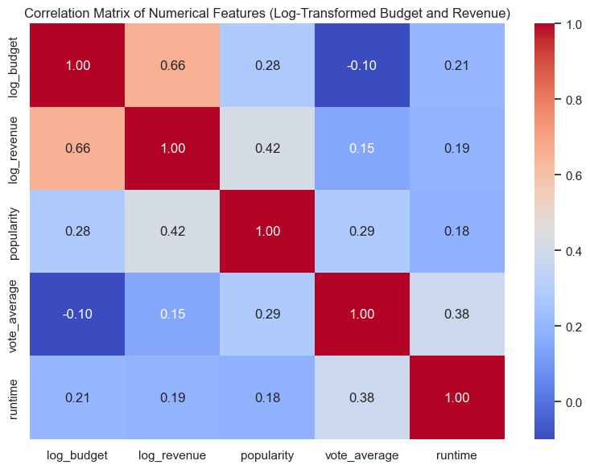

```python
# Summary statistics for numerical columns
print("Summary Statistics for Numerical Columns:\n")
print(df_analysis[['budget', 'revenue', 'popularity', 'vote_average', 'runtime']].describe())

# Correlation analysis with log-transformed budget and revenue
df_analysis['log_budget'] = np.log1p(df_analysis['budget'])
df_analysis['log_revenue'] = np.log1p(df_analysis['revenue'])

plt.figure(figsize=(8, 6))
sns.heatmap(df_analysis[['log_budget', 'log_revenue', 'popularity', 'vote_average', 'runtime']].corr(),
            annot=True, cmap='coolwarm', fmt='.2f')
plt.title('Correlation Matrix of Numerical Features (Log-Transformed Budget and Revenue)')
plt.tight_layout()
plt.show()
```

### 📊 Insights: Correlation Matrix Heatmap

We visualize the correlations between key numerical features of the movie dataset, including log-transformed **budget** and **revenue** to handle skewed distributions. The heatmap highlights relationships such as:

• A **strong positive correlation** between log-budget and log-revenue, indicating that higher movie budgets are generally associated with higher revenues.  
• Moderate relationships between popularity and financial metrics, suggesting that popular movies often perform better financially.  
• Weak correlations between vote average and financial figures, showing that critical reception does not always align with budget or revenue.  
• Runtime shows modest correlations with other variables.

This analysis helps uncover patterns linking financial performance, audience reception, and movie characteristics.

## 📈 Additional Visualizations

We create visualizations to explore **genre popularity**, **vote ratings**, **budget vs. revenue**, and **keyword trends** over time. These align with the project's goal of analyzing cultural shifts through movie metadata, using log-scaled financial metrics and filtered keywords for clarity.

These plots provide a multi-faceted view of cultural and financial trends in cinema.

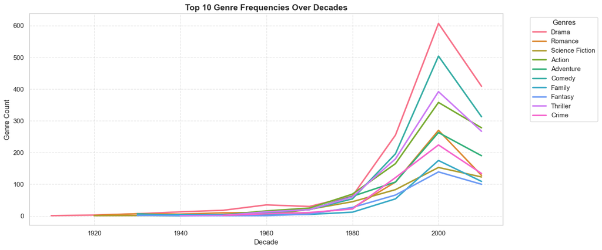

```python
# Visualization 1: Genre Frequency Over Decades
genre_counts = df_analysis.explode('genres_list').groupby(['decade', 'genres_list']).size().reset_index(name='count')
top_genres = genre_counts.groupby('genres_list')['count'].sum().nlargest(10).index
filtered_genre_counts = genre_counts[genre_counts['genres_list'].isin(top_genres)]

plt.figure(figsize=(12, 6))
sns.set_palette("husl")  # Vibrant
sns.lineplot(data=filtered_genre_counts, x='decade', y='count', hue='genres_list', linewidth=2.5)
plt.title('Top 10 Genre Frequencies Over Decades', fontsize=14, weight='bold')
plt.xlabel('Decade')
plt.ylabel('Genre Count')
plt.grid(True, linestyle='--', alpha=0.5)
plt.tight_layout()
plt.legend(title='Genres', bbox_to_anchor=(1.05, 1), loc='upper left')
plt.show()
```

### 🎬 Insights: Genre Frequency Over Decades

We analyze how the **popularity of movie genres** has changed across different decades by plotting the frequency of the top 10 genres over time.

The line chart reveals patterns such as:  
• Certain genres gaining popularity in modern decades, reflecting evolving cultural tastes.  
• Some genres maintaining consistent production levels over time, indicating lasting audience interest.  
• Periods where specific genres spiked in frequency, possibly due to social trends, technological advances, or major hits in those genres.

This visualization helps trace **cultural shifts** and understand how filmmakers and studios respond to changing audience preferences.

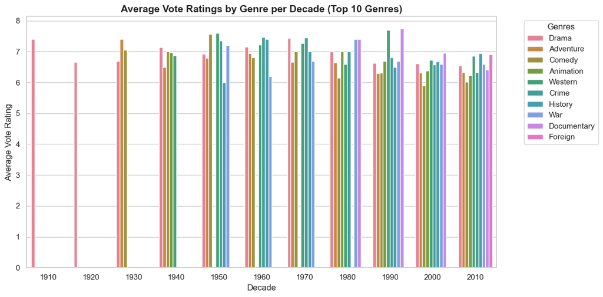

```python
# Visualization 2: Average Vote Ratings by Genre per Decade
vote_by_genre = df_analysis.groupby(['decade', 'primary_genre'])['vote_average'].mean().reset_index()
top_genres_vote = vote_by_genre.groupby('primary_genre')['vote_average'].mean().nlargest(10).index
filtered_vote = vote_by_genre[vote_by_genre['primary_genre'].isin(top_genres_vote)]

plt.figure(figsize=(12, 6))
sns.set_palette("Set2")  # Clean & distinct
sns.barplot(x='decade', y='vote_average', hue='primary_genre', data=filtered_vote)
plt.title('Average Vote Ratings by Genre per Decade (Top 10 Genres)', fontsize=14, weight='bold')
plt.xlabel('Decade')
plt.ylabel('Average Vote Rating')
plt.legend(title='Genres', bbox_to_anchor=(1.05, 1), loc='upper left')
plt.tight_layout()
plt.show()
```

### ⭐ Insights: Average Vote Ratings by Genre per Decade

This bar chart illustrates how **audience ratings** for the top 10 movie genres have changed over the decades.

Key insights include:  
• Some genres consistently receive **higher average ratings**, suggesting strong audience appreciation across time.  
• Variations in ratings reveal **shifting audience tastes** and changing perceptions of different genres.  
• Peaks or drops in certain decades may reflect cultural trends, societal events, or standout films influencing genre reputation.

This visualization helps link **genre popularity** to audience satisfaction, providing cultural context to movie trends.

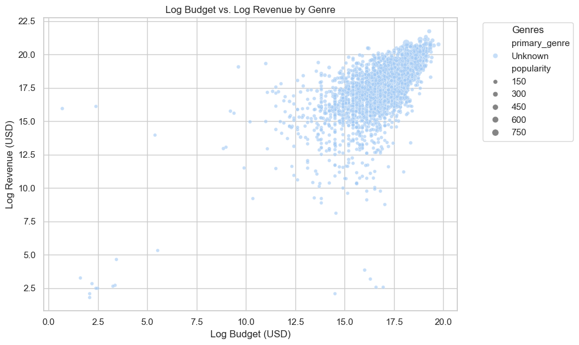

```python
# Visualization 3: Budget vs. Revenue Scatter Plot (Log-Scaled)
plt.figure(figsize=(10, 6))
sns.scatterplot(x='log_budget', y='log_revenue', hue='primary_genre', size='popularity', data=df_analysis, alpha=0.6)
plt.title('Log Budget vs. Log Revenue by Genre')
plt.xlabel('Log Budget (USD)')
plt.ylabel('Log Revenue (USD)')
plt.legend(title='Genres', bbox_to_anchor=(1.05, 1), loc='upper left')
plt.tight_layout()
plt.show()
```

### 💰 Insights: Budget vs. Revenue Scatter Plot (Log-Scaled)

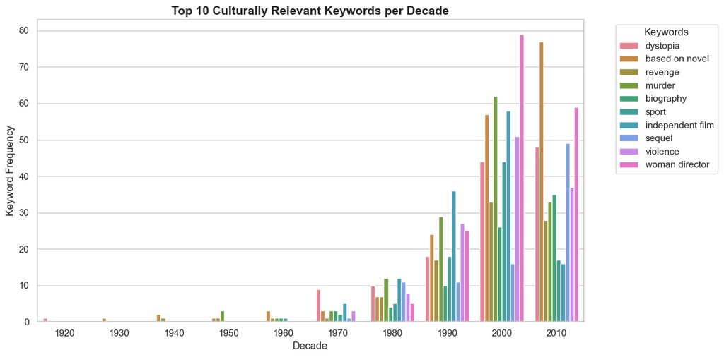

```python
# Visualization 4: Top Culturally Relevant Keywords per Decade
exclude_keywords = ['aftercreditsstinger', 'duringcreditsstinger', '3d', 'imax']
keyword_counts = df_analysis.explode('keywords_list')
keyword_counts = keyword_counts[~keyword_counts['keywords_list'].isin(exclude_keywords)]
keyword_counts = keyword_counts.groupby(['decade', 'keywords_list']).size().reset_index(name='count')
top_keywords = keyword_counts.groupby('keywords_list')['count'].sum().nlargest(10).index
filtered_keyword_counts = keyword_counts[keyword_counts['keywords_list'].isin(top_keywords)]

plt.figure(figsize=(12, 6))
sns.set_palette("Dark2")  # Distinct and sharp
sns.barplot(x='decade', y='count', hue='keywords_list', data=filtered_keyword_counts)
plt.title('Top 10 Culturally Relevant Keywords per Decade', fontsize=14, weight='bold')
plt.xlabel('Decade')
plt.ylabel('Keyword Frequency')
plt.legend(title='Keywords', bbox_to_anchor=(1.05, 1), loc='upper left')
plt.tight_layout()
plt.show()
```

### 🔑 Insights: Top Culturally Relevant Keywords per Decade

This bar chart highlights the **most frequently used keywords** in movie metadata across different decades, revealing cultural themes reflected in films over time.

Key insights include:  
• Certain keywords emerge strongly in specific decades, reflecting **social trends, historical events, or popular storytelling themes**.  
• Persistent keywords indicate topics with **enduring cultural significance**.  
• Filtering out technical or generic keywords ensures focus on **meaningful cultural signals**.

This visualization provides a lens into how **cultural interests and narratives evolve** in cinema.

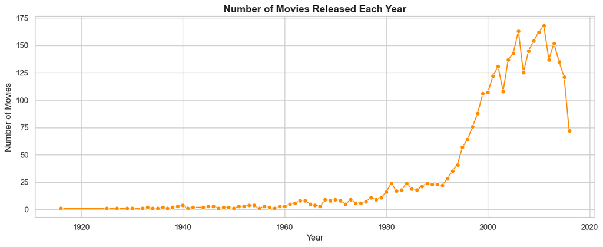

```python
# Visualization 5: number of movies released each year
movies_per_year = df_analysis['year'].value_counts().sort_index()

plt.figure(figsize=(12, 5))
sns.set_style("whitegrid")
sns.lineplot(x=movies_per_year.index, y=movies_per_year.values, marker='o', color='darkorange')
plt.title('Number of Movies Released Each Year', fontsize=14, weight='bold')
plt.xlabel('Year')
plt.ylabel('Number of Movies')
plt.tight_layout()
plt.show()
```

### 🎥 Insights: Number of Movies Released Each Year

This line plot shows how **movie production has varied year by year** in the dataset.

Key insights include:  
• Overall **growth trends** in the number of films produced, reflecting expansion in the film industry.  
• **Fluctuations or drops** in certain years may correspond to significant global events or industry changes.  
• Helps identify **peak production periods**, offering insights into cultural and economic factors driving filmmaking activity.

This visualization provides a timeline of how the **volume of movies evolved** over time.

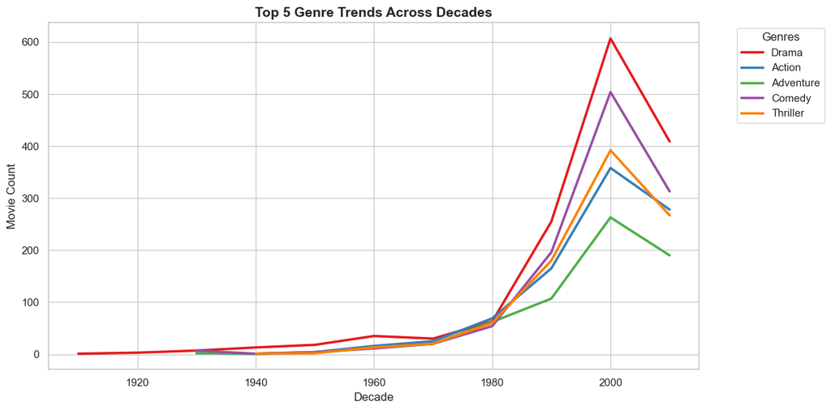

```python
# Visualization 6: Genre Trends Across Decades
genre_decade = df_analysis.explode('genres_list').groupby(['decade', 'genres_list']).size().reset_index(name='count')
top_genres = genre_decade.groupby('genres_list')['count'].sum().nlargest(5).index
filtered_genre_trends = genre_decade[genre_decade['genres_list'].isin(top_genres)]

plt.figure(figsize=(12, 6))
sns.set_palette("Set1")  # Bold and easily distinguishable
sns.lineplot(data=filtered_genre_trends, x='decade', y='count', hue='genres_list', linewidth=2.5)
plt.title('Top 5 Genre Trends Across Decades', fontsize=14, weight='bold')
plt.xlabel('Decade')
plt.ylabel('Movie Count')
plt.legend(title='Genres', bbox_to_anchor=(1.05, 1), loc='upper left')
plt.tight_layout()
plt.show()
```

### 🎬 Insights: Genre Trends Across Decades

This line plot shows how the **popularity of the top 5 movie genres** has evolved across different decades.

Key insights include:  
• Some genres **rise or decline sharply**, reflecting changing cultural tastes and audience preferences over time.  
• Certain genres show **consistent popularity**, indicating enduring audience interest.  
• Helps uncover how shifts in society, technology, or global events may influence genre trends in cinema.

This visualization captures **cultural shifts** and long-term trends in movie production by genre.

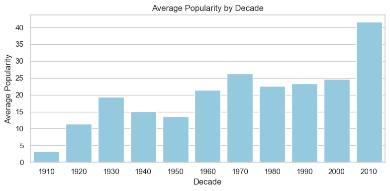

```python
# Visualization 7: Average Popularity Across Decades
pop_by_decade = df_analysis.groupby('decade')['popularity'].mean()

plt.figure(figsize=(8, 4))
sns.barplot(x=pop_by_decade.index, y=pop_by_decade.values, color='skyblue')
plt.title('Average Popularity by Decade')
plt.xlabel('Decade')
plt.ylabel('Average Popularity')
plt.tight_layout()
plt.show()
```

### 🌟 Insights: Average Popularity Across Decades

This bar chart displays the **average popularity of movies** in each decade, helping reveal shifts in audience engagement and cultural interest over time.

Key insights include:  
• Decades with higher averages may indicate **booming audience interest** or changes in how popularity is measured.  
• Drops or peaks could reflect **technological changes, industry trends, or societal events** affecting movie visibility.  
• Helps understand **long-term patterns** in audience enthusiasm and cinematic influence.

This visualization provides a snapshot of how **movie popularity evolved** over the decades.

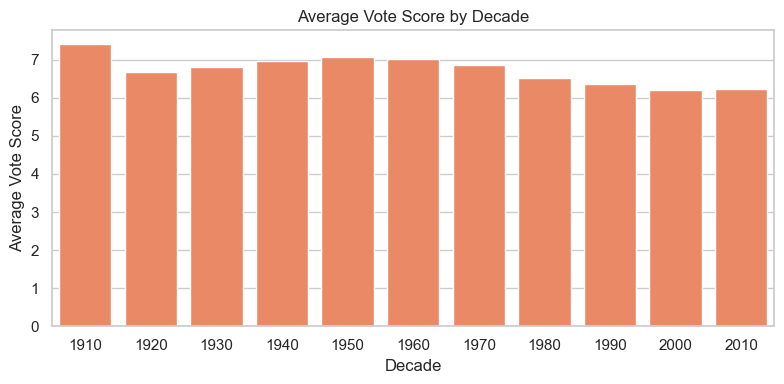

```python
#Visualization 8: Average Vote Score Across Decades
vote_by_decade = df_analysis.groupby('decade')['vote_average'].mean()

plt.figure(figsize=(8, 4))
sns.barplot(x=vote_by_decade.index, y=vote_by_decade.values, color='coral')
plt.title('Average Vote Score by Decade')
plt.xlabel('Decade')
plt.ylabel('Average Vote Score')
plt.tight_layout()
plt.show()
```

### ⭐ Insights: Average Vote Score Across Decades

This bar chart shows the **average vote score given to movies** in each decade, offering insights into how audience or critic ratings have evolved over time.

Key insights include:  
• Variations across decades may reveal **changes in audience expectations or critical standards**.  
• Higher average scores in certain periods could reflect **stronger filmmaking trends or popular genres**.  
• Helps assess **overall shifts in perceived movie quality** over the decades.

This visualization captures how **cinematic quality and reception** have trended through time.

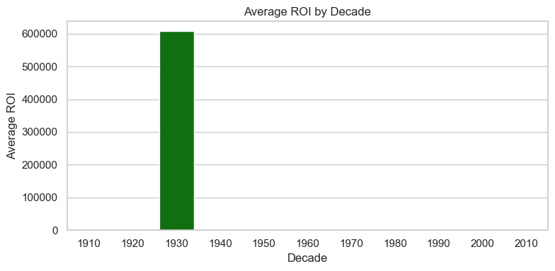

```python
#Visualization 9: ROI Trends Across Decades
roi_by_decade = df_analysis.groupby('decade')['ROI'].mean()

plt.figure(figsize=(8, 4))
sns.barplot(x=roi_by_decade.index, y=roi_by_decade.values, color='green')
plt.title('Average ROI by Decade')
plt.xlabel('Decade')
plt.ylabel('Average ROI')
plt.tight_layout()
plt.show()
```

### 💰 Insights: ROI Trends Across Decades

This bar chart displays the **average Return on Investment (ROI)** for movies in each decade, offering insights into how film profitability has shifted over time.

Key insights include:  
• Higher average ROI in certain decades may reflect **booming industry periods, popular genres, or lower production costs relative to revenue**.  
• Declines could indicate **rising budgets without proportional revenue growth, market saturation, or shifts in audience spending habits**.  
• Helps understand the **financial landscape and risk/reward balance** in the film industry across eras.

This visualization reveals how **financial performance in cinema** has evolved over time.

```python
#Top Movies by ROI
roi_df = df_analysis.replace([np.inf, -np.inf], np.nan)
roi_df = roi_df.dropna(subset=['ROI'])
top_roi = roi_df.sort_values(by='ROI', ascending=False).head(10)
top_roi[['title', 'year', 'budget', 'revenue', 'ROI']]
```

|  | title | year | budget | revenue | ROI |
| --- | --- | --- | --- | --- | --- |
| 4238 | Modern Times | 1936 | 1 | 8500000 | 8.499999e+06 |
| 3137 | Nurse 3-D | 2013 | 10 | 10000000 | 9.999990e+05 |
| 4577 | Paranormal Activity | 2007 | 15000 | 193355800 | 1.288939e+04 |
| 4582 | Tarnation | 2003 | 218 | 1162014 | 5.329339e+03 |
| 4496 | The Blair Witch Project | 1999 | 60000 | 248000000 | 4.132333e+03 |
| 4724 | Eraserhead | 1977 | 10000 | 7000000 | 6.990000e+02 |
| 4788 | Pink Flamingos | 1972 | 12000 | 6000000 | 4.990000e+02 |
| 4742 | Super Size Me | 2004 | 65000 | 28575078 | 4.386166e+02 |
| 4723 | The Gallows | 2015 | 100000 | 42664410 | 4.256441e+02 |
| 4514 | Open Water | 2004 | 130000 | 54667954 | 4.195227e+02 |

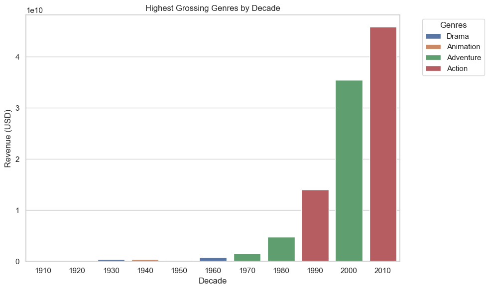

```python
# Visualization 10: Highest-grossing genres by decade
highest_grossing = df_analysis.groupby(['decade', 'primary_genre'])['revenue'].sum().groupby('decade').nlargest(1).reset_index(level=0, drop=True).reset_index()

plt.figure(figsize=(10, 6))
sns.barplot(x='decade', y='revenue', hue='primary_genre', data=highest_grossing)
plt.title('Highest Grossing Genres by Decade')
plt.xlabel('Decade')
plt.ylabel('Revenue (USD)')
plt.legend(title='Genres', bbox_to_anchor=(1.05, 1), loc='upper left')
plt.tight_layout()
plt.show()
```

### 💵 Insights: Highest-Grossing Genres by Decade

This bar chart shows the **top-earning movie genre in each decade**, highlighting which genres dominated the box office financially over time.

Key insights include:  
• Certain genres consistently **lead in revenue**, reflecting enduring audience appeal and market strength.  
• Shifts in dominant genres reveal how **audience preferences and industry focus** change across decades.  
• Helps connect **financial success with cultural trends**, showing how popular stories translate into box office results.

This visualization captures the **financial champions of cinema** across different eras.

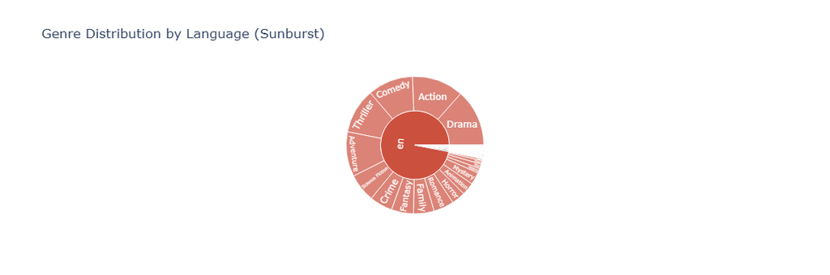

```python
# Visualization 11: Genre Distribution by Original Language
# Parse genre safely
def parse_genres(val):
    if isinstance(val, str):
        try:
            return [d.get('name') for d in ast.literal_eval(val) if isinstance(d, dict) and 'name' in d]
        except:
            return []
    return []

# Apply parsing
df['genres'] = df['genres'].apply(parse_genres)

# Explode and clean
df_genres = df.explode('genres')
df_genres = df_genres.dropna(subset=['genres', 'original_language'])
df_genres = df_genres[df_genres['genres'].str.strip() != '']

# Create sunburst
fig = px.sunburst(
    df_genres,
    path=['original_language', 'genres'],
    values='popularity',
    title='Genre Distribution by Language (Sunburst)',
    color='original_language',
    color_discrete_sequence=px.colors.qualitative.Prism
)
fig.show()
```

### 🎬 Insights: Genre Distribution by Original Language

This sunburst chart visualizes how **movie genres are distributed across different original languages**, offering a layered view into the relationship between language and cinematic storytelling.

Key insights include:  
• The center of the chart shows **original languages**, with branches extending outward to reveal genres linked to each language.  
• The size of each segment reflects the **popularity** of movies within that genre-language combination.  
• Bright, distinct colors help **differentiate languages**, making it easy to explore patterns and trends.  
• Highlights how **cultural and regional preferences** shape the popularity of certain genres around the world.

This visualization uncovers the **rich diversity of global cinema** through the lens of language and genre.

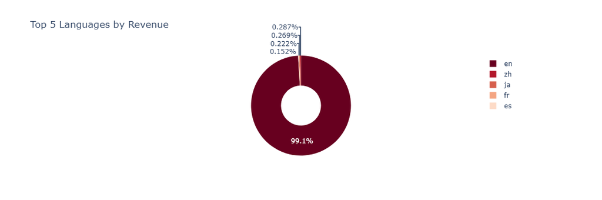

```python
# Visualization 12: Top 5 Languages by Total Revenue
lang_revenue = df.groupby('original_language')['revenue'].sum().sort_values(ascending=False).head(5).reset_index()

fig = px.pie(
    lang_revenue,
    names='original_language',
    values='revenue',
    title='Top 5 Languages by Revenue',
    hole=0.4,  # Donut style
    color_discrete_sequence=px.colors.sequential.RdBu
)
fig.show()
```

### 💰 Insights: Top 5 Languages by Total Revenue

This donut chart displays the **five original languages that generated the highest total revenue** across all movies in the dataset, highlighting the dominant linguistic markets in global cinema.

Key insights include:  
• The chart shows how **revenue is concentrated** among a few key languages.  
• Larger slices indicate languages with **significantly higher box office earnings**.  
• The color gradient helps **visually separate each language**, making trends clear at a glance.  
• Useful for understanding **market size and potential audience reach** for films produced in different languages.

This visualization reveals the **financial powerhouses of global film industries** through the lens of language.

```python
# Visualization 13: Movies by Production Country
# Extract countries
df['production_countries'] = df['production_countries'].apply(lambda x: [i['name'] for i in ast.literal_eval(x)] if pd.notnull(x) else [])
df_countries = df.explode('production_countries')

# Sample 100 records with fake lat/lng
sampled = df_countries[['title', 'production_countries']].dropna().sample(100)
sampled['lat'] = sampled['production_countries'].apply(lambda x: random.uniform(-60, 60))
sampled['lon'] = sampled['production_countries'].apply(lambda x: random.uniform(-180, 180))

# Create map
m = folium.Map(location=[20, 0], zoom_start=2)
for _, row in sampled.iterrows():
    folium.Marker(
        location=[row['lat'], row['lon']],
        popup=f"{row['title']} ({row['production_countries']})"
    ).add_to(m)
m.save("map_visualization.html")
m
```

Make this Notebook Trusted to load map: File -> Trust Notebook

[interactive chart not shown]

### 🌍 Insights: Movies by Production Country

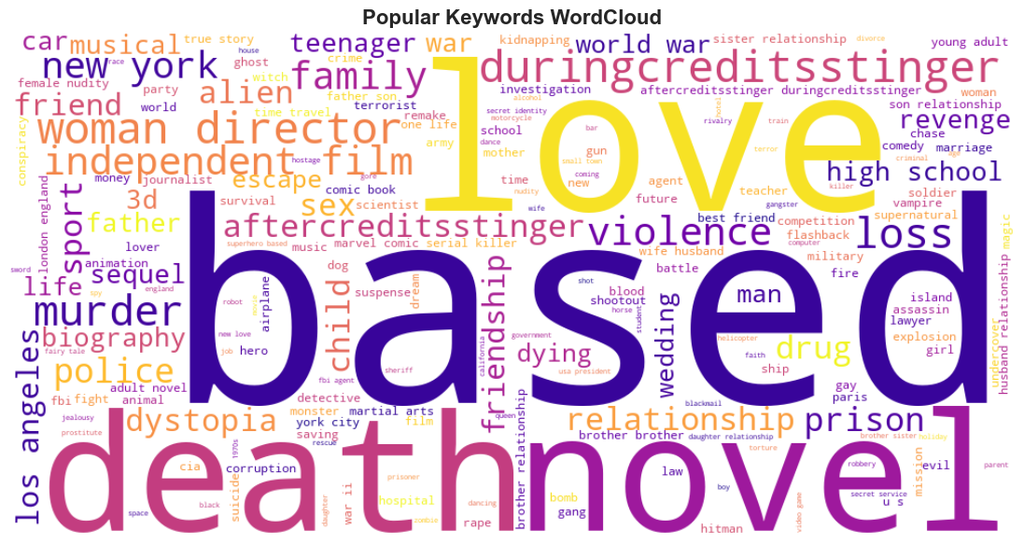

```python
# Visualization 14: Poupular Keywords Wordcloud
keywords_flat = df_analysis['keywords_list'].explode().dropna().tolist()
keywords_string = ' '.join(keywords_flat)

wordcloud = WordCloud(
    width=1000,
    height=500,
    background_color='white',
    colormap='plasma',
    max_words=200,
    contour_color='steelblue',
    contour_width=1.5
).generate(keywords_string)

plt.figure(figsize=(14, 7))
plt.imshow(wordcloud, interpolation='bilinear')
plt.axis('off')
plt.title('Popular Keywords WordCloud', fontsize=16, weight='bold')
plt.show()
```

### 🔑 Insights: Popular Keywords Wordcloud

This wordcloud highlights the **most frequently occurring keywords** associated with movies in the dataset, offering a visual summary of common themes, topics, and concepts in popular films.

Key insights include:  
• **Larger words** indicate keywords that appear more often across movie records.  
• Vibrant colors and varied sizes help **quickly identify prominent themes**.  
• Offers a **high-level view of storytelling trends**, such as common genres, motifs, or topics.  
• Useful for understanding **audience interests and recurring subjects** in popular cinema.

This visualization transforms text data into a **vivid snapshot of cinematic trends** through the power of keywords.

## 🎬 Conclusion and Gratitude

This project analyzed the **movies.csv** dataset to uncover cultural and financial trends in cinema. Through robust preprocessing, we parsed JSON columns, handled missing values, and derived *ROI*, *primary_genre*, and *decade* for reliable analysis. Statistical insights revealed correlations between budget, revenue, and audience metrics, while visualizations highlighted:

I extend heartfelt gratitude to the developers of **pandas**, **matplotlib**, **seaborn**, and **Jupyter Lab** for their powerful tools that enabled this analysis. Their contributions made exploring these trends possible.

This project’s success reflects the power of data-driven storytelling and collaborative open-source tools.